# Assignment-1

2024-01-22

```r
library(tidyverse)
library(knitr)
library(ggplot2)
```

#### Import Dataset

```r
setwd("/Users/apple/Desktop/8451 Machine Learning for Epi/Assignment-1")
data <- read_csv("./bcdata_Assignment1.csv")
```

#### 1. Construct a summary table

Construct a table providing summaries of the quantitative features of the dataset including mean, median, minimum value, and maximum value.

```r
# Calculate summaries
summary_table <- data.frame(
  Mean = sapply(data, mean),
  Median = sapply(data, median),
  Minimum = sapply(data, min),
  Maximum = sapply(data, max)
)

# Print the summary table
kable(summary_table)
```

|  | Mean | Median | Minimum | Maximum |
| --- | --- | --- | --- | --- |
| Age | 57.301724 | 56.000000 | 24.0000000 | 89.00000 |
| BMI | 27.582111 | 27.662416 | 18.3700000 | 38.57876 |
| Glucose | 97.793103 | 92.000000 | 60.0000000 | 201.00000 |
| Insulin | 10.012086 | 5.924500 | 2.4320000 | 58.46000 |
| HOMA | 2.694988 | 1.380939 | 0.4674087 | 25.05034 |
| Leptin | 26.615080 | 20.271000 | 4.3110000 | 90.28000 |
| Adiponectin | 10.180874 | 8.352692 | 1.6560200 | 38.04000 |
| Resistin | 14.725966 | 10.827740 | 3.2100000 | 82.10000 |
| MCP.1 | 534.647000 | 471.322500 | 45.8430000 | 1698.44000 |
| Classification | 1.551724 | 2.000000 | 1.0000000 | 2.00000 |

#### 2. Recode BMI into the WHO-defined categories

Recode BMI into the WHO-defined categories below:

- Severely underweight - BMI less than 16.5kg/m^2
- Underweight - BMI under 18.5 kg/m^2
- Normal weight - BMI greater than or equal to 18.5 to 24.9 kg/m^2
- Overweight – BMI greater than or equal to 25 to 29.9 kg/m^2
- Obesity class I – BMI 30 to 34.9 kg/m^2
- Obesity class II – BMI 35 to 39.9 kg/m^2
- Obesity class III – BMI greater than or equal to 40 kg/m^2

```r
# Recode BMI into WHO-defined categories
data$BMI_category <- cut(
  data$BMI,
  breaks = c(0, 16.5, 18.5, 25, 30, 35, 40, Inf),
  labels = c(
    "Severely underweight",
    "Underweight",
    "Normal weight",
    "Overweight",
    "Obesity class I",
    "Obesity class II",
    "Obesity class III"
  ),
  include.lowest = TRUE
)

# Check the frequency results of recoded variable
table_result <- table(data$BMI_category)
dimnames(table_result) <- list("BMI category" = names(table_result))
kable(table_result)
```

| BMI.category | Freq |
| --- | --- |
| Severely underweight | 0 |
| Underweight | 1 |
| Normal weight | 39 |
| Overweight | 37 |
| Obesity class I | 27 |
| Obesity class II | 12 |
| Obesity class III | 0 |

#### 3. Create a bar chart

Create a bar chart showing the proportion of breast cancer cases and controls within each BMI category. (That is, the graph should clearly show, what % of each BMI category are cases and what % are controls).

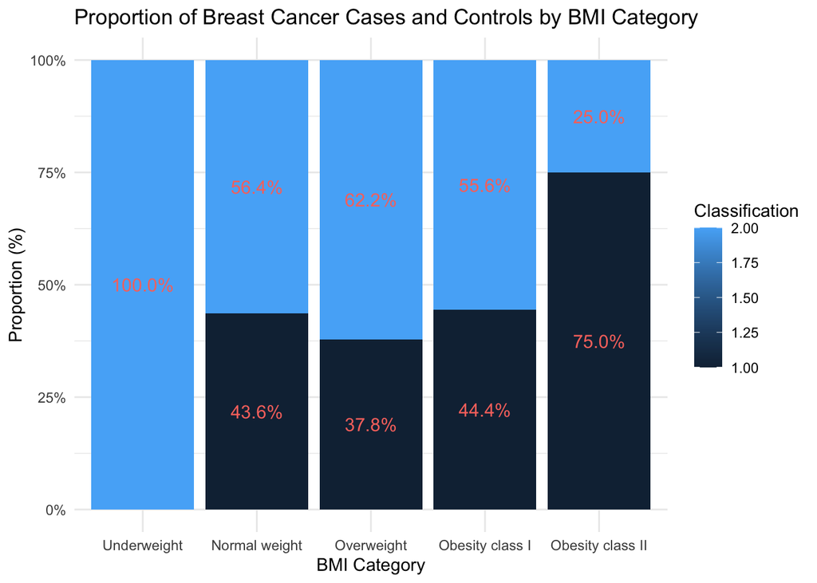

```r
# Create a data frame with the proportions
proportions_data <- data.frame(
  BMI_category = data$BMI_category,
  Classification = data$Classification
)

# Calculate proportions
proportions_data <- proportions_data %>%
  group_by(BMI_category, Classification) %>%
  summarise(Count = n()) %>%
  group_by(BMI_category) %>%
  mutate(Proportion = Count / sum(Count) * 100)

# Create a bar chart
ggplot(proportions_data, aes(x = BMI_category, y = Proportion, fill = Classification)) +
  geom_bar(stat = "identity", position = "stack") +
  geom_text(aes(label = sprintf("%.1f%%", Proportion), color = "pink"),
            position = position_stack(vjust = 0.5),
            size = 4, show.legend = FALSE) +
  labs(title = "Proportion of Breast Cancer Cases and Controls by BMI Category",
       x = "BMI Category",
       y = "Proportion (%)",
       fill = "Classification") +
  scale_y_continuous(labels = scales::percent_format(scale = 1)) +
  theme_minimal()
```

**Bar chart results:**

#### 4. Construct a logistic regression model

Construct a logistic regression model using breast cancer classification as the outcome and glucose, HOMA-IR, leptin, BMI (continuous) and age as the independent variables.

```r
# Recode 'Classification' to numeric values (0 and 1)
data$Classification_numeric <- ifelse(data$Classification == 2, 1, 0)

# Construct logistic regression model
logistic_model <- glm(Classification_numeric ~ Glucose + HOMA + Leptin + BMI + Age,
                      data = data,
                      family = "binomial")

# Summarize the model
summary(logistic_model)
```

```
##
## Call:
## glm(formula = Classification_numeric ~ Glucose + HOMA + Leptin +
##     BMI + Age, family = "binomial", data = data)
##
## Coefficients:
##              Estimate Std. Error z value Pr(>|z|)
## (Intercept) -3.626065   2.355177  -1.540 0.123654
## Glucose      0.081699   0.023526   3.473 0.000515 ***
## HOMA         0.273882   0.171976   1.593 0.111259
## Leptin      -0.008574   0.015783  -0.543 0.586979
## BMI         -0.104261   0.056642  -1.841 0.065668 .
## Age         -0.022881   0.014377  -1.592 0.111496
## ---
## Signif. codes:  0 '***' 0.001 '**' 0.01 '*' 0.05 '.' 0.1 ' ' 1
##
## (Dispersion parameter for binomial family taken to be 1)
##
##     Null deviance: 159.57  on 115  degrees of freedom
## Residual deviance: 120.81  on 110  degrees of freedom
## AIC: 132.81
##
## Number of Fisher Scoring iterations: 6
```

```r
cbind(estimate = coef(logistic_model), confint(logistic_model)) |> knitr::kable(digits = 4)
```

|  | estimate | 2.5 % | 97.5 % |
| --- | --- | --- | --- |
| (Intercept) | -3.6261 | -8.5414 | 0.7545 |
| Glucose | 0.0817 | 0.0396 | 0.1324 |
| HOMA | 0.2739 | -0.0256 | 0.6532 |
| Leptin | -0.0086 | -0.0402 | 0.0224 |
| BMI | -0.1043 | -0.2194 | 0.0044 |
| Age | -0.0229 | -0.0519 | 0.0049 |

**Logistic regression result:**

A 1-unit change in HOMA-IR is associated with the beta estimate of 0.2739 and a 95% confidence interval of (-0.0256, 0.65320).

#### 5. Construct a linear regression model

Construct a linear regression model using insulin as the outcome and BMI (continuous), age, and glucose as the independent variables.

```r
# Construct linear regression model
linear_model <- lm(Insulin ~ BMI + Age + Glucose, data = data)

# Summarize the model
summary(linear_model)
```

```
##
## Call:
## lm(formula = Insulin ~ BMI + Age + Glucose, data = data)
##
## Residuals:
##     Min      1Q  Median      3Q     Max
## -22.161  -4.359  -2.118   2.124  46.269
##
## Coefficients:
##              Estimate Std. Error t value Pr(>|t|)
## (Intercept) -13.49576    5.85941  -2.303   0.0231 *
## BMI           0.14969    0.16382   0.914   0.3628
## Age          -0.05402    0.05194  -1.040   0.3005
## Glucose       0.22982    0.03752   6.126 1.37e-08 ***
## ---
## Signif. codes:  0 '***' 0.001 '**' 0.01 '*' 0.05 '.' 0.1 ' ' 1
##
## Residual standard error: 8.731 on 112 degrees of freedom
## Multiple R-squared:  0.2675, Adjusted R-squared:  0.2479
## F-statistic: 13.64 on 3 and 112 DF,  p-value: 1.207e-07
```

```r
# Check beta coefficient and 95% CI
cbind(estimate = coef(linear_model), confint(linear_model)) |> knitr::kable(digits = 4)
```

|  | estimate | 2.5 % | 97.5 % |
| --- | --- | --- | --- |
| (Intercept) | -13.4958 | -25.1054 | -1.8861 |
| BMI | 0.1497 | -0.1749 | 0.4743 |
| Age | -0.0540 | -0.1569 | 0.0489 |
| Glucose | 0.2298 | 0.1555 | 0.3041 |

**Linear regression result:**

A 1-unit change in age is associated with the beta estimate of -0.0540 and a 95% confidence interval of (-0.1569, 0.0489).